# lqmix: an R Package for Longitudinal Data Analysis via Linear Quantile Mixtures

Marco Alfó

Department of Statistics, Sapienza, University of Rome

Maria Francesca Marino

Department of Statistics, Computer Science, Applications, University of Florence

Maria Giovanna Ranalli

Department of Political Science, University of Perugia

Nicola Salvati

Department of Economics, University of Pisa

2025-11-25

Abstract

The analysis of longitudinal data gives the chance to observe how units’ behavior changes over time, but it also poses a series of issues. These have been the focus of an extensive literature in the context of linear and generalized linear regression, moving also, in the last ten years or so, to the context of linear quantile regression for continuous responses. In this paper, we present `lqmix`, a novel `R` package that assists in estimating a class of linear quantile regression models for longitudinal data, in the presence of time-constant and/or time-varying, unit-specific, random coefficients, with unspecified distribution. Model parameters are estimated in a maximum likelihood framework via an extended EM algorithm, while the corresponding standard errors are derived via a block-bootstrap procedure. The analysis of a benchmark dataset is used to give details on the package functions.

# Introduction

Quantile regression (R. Koenker and Bassett 1978) has become quite a popular technique to model the effect of observed covariates on the conditional quantiles of a continuous response of interest. This represents a well-established practice for the analysis of data when the focus goes beyond the conditional mean. Comprehensive reviews on this topic can be found, among others, in (R. Koenker and Hallock 2001), (Yu, Lu, and Stander 2003), (R. Koenker 2005), and (Hao and Naiman 2007).

With longitudinal data, dependence between observations recorded from the same statistical unit needs to be taken into account to avoid bias and inefficiency in parameter estimates. Different modeling alternatives are available in the literature for handling such a dependence. For a general presentation, see e.g., (Diggle et al. 2002) and (Fitzmaurice, Laird, and Ware 2012), while for a focus on quantile regression see (M. F. Marino and Farcomeni 2015). Here, we consider quantile regression models that include unit-specific random coefficients to describe such a dependence; this gives rise to a conditional model specification which allows one to draw unit-level inferential conclusions on the effect of covariates on the longitudinal outcome of interest. In this framework, a standard way of proceeding is based on specifying a parametric distribution for the random coefficients, as suggested, e.g., by (Geraci and Bottai 2007, 2014). An alternative consists in leaving such a distribution unspecified and estimating it from the observed data, by using a finite mixture specification. This can arise from discrete, unit-specific, random coefficients with unspecified distribution that remains constant or evolves over time according to a hidden Markov chain, as proposed by (Alfó, Salvati, and Ranalli 2017) and (Farcomeni 2012), respectively. A more flexible specification based on combining both time-constant (TC) and time-varying (TV), unit-specific, discrete, random coefficients may also be adopted, as proposed by (Maria Francesca Marino, Tzavidis, and Alfò 2018). When compared to fully parametric alternatives, this semi-parametric approach offers a number of specific advantages, as it helps (*i*) avoid unverifiable assumptions on the random coefficient distribution; (*ii*) account for extreme and/or asymmetric departures from the homogeneous model; (*iii*) avoid integral approximations and, thus, considerably reduce the computational effort for parameter estimation.

In this paper, we describe the R package (R Core Team 2019) `lqmix` (Maria Francesca Marino et al. 2025), available from the Comprehensive R Archive Network (CRAN) at `https://CRAN.R-project.org/package=lqmix`, which is intended to provide maximum likelihood (ML) estimates for TC and/or TV mixtures of linear quantile regression models for longitudinal data. An indirect estimation approach, based on an extended Expectation-Maximization algorithm (EM - Dempster, Laird, and Rubin 1977) is employed.

The package `lqmix` shares features with some relevant R packages available for the analysis of longitudinal data on the CRAN repository. It is related to packages `lme4` (Bates et al. 2015) and `lqmm` (Geraci 2014) tailored, respectively, to the analysis of general clustered observations via mixed models for the conditional mean and the conditional quantiles of a response. Here, TC random coefficients following a parametric distribution are considered to model dependence between observations and a ML approach is employed to derive parameter estimates. `lqmix` is also strongly related to the `LMest` R package (Bartolucci, Pandolfi, and Pennoni 2017). This allows modeling the mean of longitudinal observations via hidden Markov models (Zucchini and MacDonald 2009; Bartolucci, Farcomeni, and Pennoni 2013). In this case, TV random coefficients with unspecified distribution that evolves over time according to a Markov chain are considered to account for dependence between measures from the same unit and a ML approach is adopted to derive parameter estimates. Other R packages that can be fruitfully related to `lqmix` are `rqpd` (Roger Koenker and Bache 2014), `pqrfe` (Danilevicz, Reisen, and Bondon 2022), and `npmlreg` (Einbeck, Darnell, and Hinde 2018). The former allows for the estimation of linear quantile regression models for panel data by considering either a penalized fixed effect estimation (R. Koenker 2004) or a correlated random-effect method (Abrevaya and Dahl 2008). In both cases, parameters are estimated by minimizing an extended quantile loss function. Similarly, `pqrfe` allows for the estimation of quantile regression models for longitudinal data based on unit-specific fixed effects; three different estimation methods are implemented, each based on the minimization of a different loss function. Last, the `npmlreg` R package entails mixtures of (generalized) linear models for clustered observations by employing a ML approach for parameter estimation. Finally, it is worth mentioning the `quantreg` R package (R. Koenker 2022) for estimation and inference in linear models for conditional quantiles. Comparing these alternative packages with `lqmix`, it is worth highlighting that the latter fills in a blank by providing modeling tools not available in these other packages and ensures greater flexibility thanks to the non-parametric nature of the random coefficient distribution, which allows to avoid untestable parametric assumptions. The second benefit of `lqmix` entails the modeling of quantiles rather than the mean. Quantile regression allows one to analyze the impact that predictors may have on different parts of the conditional response distribution, as well as to deal with outliers and/or heavy tails that make the Gaussian assumption typically used for continuous data unreliable.

The paper is structured as follows. The different proposals available in the literature on finite mixtures of linear quantile regression models are described in Section 2, where the case of TC, TV, and the combination of TC and TV random coefficients are discussed. ML estimation is reviewed in Section 3, where details on the EM algorithm and the bootstrap procedure for standard error estimation are described. The proposed R package is presented in Section 4, where the analysis of a benchmark dataset is discussed. Further methods available for the main functions of the package and not presented in Section 4 are discussed in Section 5, while Section 6 describes the function to estimate linear quantile regression for independent data. Finally, Section 7 contains some concluding remarks.

# Modeling alternatives

Let us consider the case in which a longitudinal study is planned to record the value of a continuous response variable $Y$ and a set of covariates (or predictors or explanatory variables) on a sample of $n$ statistical units, at $T$ different measurement occasions. We assume a balanced study, with common (at least in unit-time) and equally spaced occasions, in discrete time. Let $Y_{it}$ denote the value of the response for unit $i=1, \dots, n,$ at occasion $t = 1, \dots, T,$ and $y_{it}$ the corresponding realization. Further, let $\boldsymbol{\mathbf{Y}}_i = (Y_{i1}, \dots, Y_{iT})^\prime$ and $\boldsymbol{\mathbf{y}}_i = (y_{i1}, \dots, y_{iT})^\prime$ be the $T$-dimensional vector of responses for unit $i$ and its realization, respectively. A frequent issue to address when dealing with longitudinal studies is that of missingness. This may entail both the response and the covariates. Here, we assume that the latter are fully observed, while an ignorable missingness (Rubin 1976) may affect the outcome. That is, some units in the sample may present incomplete response sequences due to either monotone or non-monotone missing data patterns (Little and Rubin 2002). In this sense, a varying number of measures $T_i$ may be available for each unit, even though missingness is assumed to be independent from unobserved responses – M(C)AR assumption.

Random coefficient models represent a standard approach to analyze the effect of observed covariates on a response $Y$ that is repeatedly observed over time. This also holds in the quantile regression framework, where the interest is in modeling the conditional quantiles of the response distribution as a function of fixed and random coefficients. To ensure flexibility and avoid unverifiable parametric assumptions on the random coefficient distribution, a specification based on finite mixtures represents a viable strategy to adopt. For this purpose, we developed the `lqmix` R package.

In this section, we describe the methodology underlying the proposed package, and present some alternative formulations of quantile regression models available in the literature to deal with longitudinal data. In detail, we consider models based on discrete, unit-specific, random coefficients with unspecified distribution to capture unit-specific sources of unobserved heterogeneity due to omitted covariates. According to the chosen specification, these random coefficients may remain constant and/or evolve over time, leading to a model based on TC, TV, or both TC and TV random coefficients, respectively. The following sections present each of these formulations in detail.

## Linear quantile mixtures with TC random coefficients

For a given quantile level $q \in(0,1)$, let $\boldsymbol{\mathbf{\beta}}_q$ denote a quantile-dependent, $p$-dimensional, vector of parameters associated with the (design) vector $\boldsymbol{\mathbf{x}}_{it}= (x_{it1}, \dots, x_{itp})^{\prime}$. Also, let $\boldsymbol{\mathbf{z}}_{it} = (z_{it1}, \dots, z_{itd})^\prime$ denote a set of $d \ge 1$ covariates (not included in $\boldsymbol{\mathbf{x}}_{it}$) associated with a vector of unit- and quantile-specific random coefficients $\boldsymbol{\mathbf{b}}_{i,q}=(b_{i1,q}, \dots, b_{id,q})^\prime$. This latter accounts for unobserved heterogeneity that is not captured by the elements in $\boldsymbol{\mathbf{x}}_{it}$ and may be used to describe dependence between repeated measurements from the same unit. In this sense, conditional on $\boldsymbol{\mathbf{b}}_{i,q}$, the longitudinal responses $Y_{i1}, \dots, Y_{it}$ are assumed to be independent of each other (local independence assumption). Moreover, for a given quantile level $q \in (0,1)$ and conditional on the vector $\boldsymbol{\mathbf{b}}_{i,q}$, the response $Y_{it}$ is assumed to follow an Asymmetric Laplace Distribution (ALD - e.g., Yu and Moyeed 2001), with density
$$f_{y \mid b} (y_{it} \mid
\boldsymbol{\mathbf{b}}_{i,q}; q) =
\left[\frac{q (1-q)}{ \sigma_q}\right] \exp \left\{ -\rho_q \left[
\frac{ y_{it} - \mu_{it,q}
}
{\sigma_q} \right] \right\}.$$
Here, $\rho_q(\cdot)$ denotes the quantile asymmetric loss function (R. Koenker and Bassett 1978), while $q, \sigma_q$, and $\mu_{it,q}$ denote the skewness, the scale, and the location parameter of the distribution, respectively. The ALD is a working model that is used to recast estimation of parameters for the linear quantile regression model in a maximum likelihood framework. The location parameter of the ALD, $\mu_{it,q}$, is modeled as
$$\label{eq:TCmodel_Par}
\mu_{it,q} = \boldsymbol{\mathbf{x}}_{it}^\prime
\boldsymbol{\mathbf{\beta}}_q + \boldsymbol{\mathbf{z}}_{it}^\prime
\boldsymbol{\mathbf{b}}_{i,q}. (\#eq:TCmodel-Par)$$

The modeling structure is completed by the mixing distribution $f_{b,q}({\boldsymbol{\mathbf{b}}}_{i,q}; {\boldsymbol{\mathbf{\Sigma}}}_{q})$, i.e., the distribution of the random coefficients ${\boldsymbol{\mathbf{b}}}_{i,q}$, where $\boldsymbol{\mathbf{\Sigma}}_q$ identifies a (possibly) quantile-dependent covariance matrix. Rather than specifying such a distribution parametrically as in, e.g., (Geraci and Bottai 2014), (Alfó, Salvati, and Ranalli 2017) proposed to leave it unspecified and use a NonParametric Maximum Likelihood approach (NPML – Laird 1978; Lindsay 1983b, 1983a) to estimate it directly from the observed data. This approach is known to lead to the estimation of a (quantile-specific) discrete mixing distribution defined over the set of locations $\{\boldsymbol{\mathbf{\zeta}}_{1,q}, \dots, \boldsymbol{\mathbf{\zeta}}_{G_q,q}\}$, with mixture probabilities $\pi_{g,q} = \Pr(\boldsymbol{\mathbf{b}}_{i,q} = \boldsymbol{\mathbf{\zeta}}_{g,q})$, $i = 1, \dots, n, \, g = 1, \dots, G_q$, and $G_q\leq n$. Under this approach, for $\boldsymbol{\mathbf{b}}_{i,q}= \boldsymbol{\mathbf{\zeta}}_{g,q}$, the location parameter of the ALD in Equation @ref(eq:TCmodel-Par) becomes
$$%\label{eq:TCmodel}
\mu_{itg,q} = \boldsymbol{\mathbf{x}}_{it}^\prime
\boldsymbol{\mathbf{\beta}}_q + \boldsymbol{\mathbf{z}}_{it}^\prime
\boldsymbol{\mathbf{\zeta}}_{g,q}, (\#eq:TCmodel)$$
while the model likelihood is defined by the following expression:
$$\label{eq:TClk}
L(\cdot \mid q) =\prod_{i = 1}^{n} \sum_{g = 1}^{G_q} \left[\prod_{t =
1}^{T_i} f_{y\mid b}(y_{it} \mid \boldsymbol{\mathbf{b}}_{i,q} =
\boldsymbol{\mathbf{\zeta}}_{g,q}; q)\right]
\pi_{g,q}. (\#eq:TClk)$$
This equation clearly resembles the likelihood of a finite mixture of linear quantile regression models with TC, discrete, random coefficients.

## Linear quantile mixtures with TV random coefficients

While the model specification introduced in the previous section accounts for unit-specific omitted covariates, it may fall short in handling time variations in such unobserved heterogeneity. To address this limitation (Farcomeni 2012) introduced a linear quantile regression model with TV, discrete, random intercepts. Rather than allowing the distribution of these intercepts to vary freely, it is modeled via a discrete-time Markov chain that ensures parsimony and interpretability. While such a proposal entails unit-specific intercepts only, a broader specification with general TV, discrete, random coefficients can also be considered.

As before, let $\boldsymbol{\mathbf{x}}_{it}= (x_{it1}, \dots, x_{itp})^{\prime}$ denote a vector of $p$ covariates associated with the vector of parameters $\boldsymbol{\mathbf{\beta}}_{q} = (\beta_{1,q}, \dots, \beta_{p,q})^{\prime}$. Further, let $\boldsymbol{\mathbf{w}}_{it} = (w_{it1}, \dots, w_{itl})^\prime$ denote a set of $l\geq 1$ explanatory variables not included in $\boldsymbol{\mathbf{x}}_{it}$, associated with a vector of unit-, time-, and quantile-specific random coefficients $\boldsymbol{\mathbf{\alpha}}_{it,q} = (\alpha_{it1,q}, \dots, \alpha_{itl,q})^\prime$. These are assumed to evolve over time according to a homogeneous, first order, hidden Markov chain $\{S_{it,q}\}$ that depends on the specified quantile level $q$. In detail, $\{S_{it,q}\}$ is defined over the finite state space $\mathcal{S}_q = \{1, \dots, m_q\}$, with initial and transition probabilities $\delta_{s_{i1,q},q}$ and $\gamma_{s_{it,q}|s_{it-1,q},q}$, defined as:
$$\delta_{s_{i1,q},q} = \Pr(S_{i1,q} =
s_{i1,q})$$
and
$$\gamma_{s_{it,q}|s_{it-1,q},q} = \Pr(S_{it,q} =
s_{it,q}\mid S_{it-1,q} = s_{it-1,q}).$$

As for the model based on TC random coefficients detailed above, local independence holds, together with the convenient assumption of conditional ALD for the responses. For a given quantile level $q \in (0,1)$, the joint conditional distribution of the observed $T_i$-dimensional response vector $\boldsymbol{\mathbf{y}}_i = (y_{i1}, \dots, y_{iT_i})^\prime$ is given by
$$f_{y
\mid s} (\boldsymbol{\mathbf{y}}_i \mid \boldsymbol{\mathbf{s}}_{i,q};
q) = f_{y \mid s}(y_{i1} \mid {s_{i1,q}}; q) \prod_{t = 2}^{T_i} f_{y
\mid s}(y_{it} \mid s_{it,q}; q).$$
Here, $\boldsymbol{\mathbf{s}}_{i,q} = (s_{i1,q}, \dots, s_{iT_i,q})^\prime$ is the vector of states visited by the $i$-th unit and $f_{y \mid s}(y_{it} \mid s_{it,q}; q)$ denotes the Asymmetric Laplace density with skewness $q$, scale $\sigma_q$, and location parameter $\mu_{its_{it,q}, q}$. This latter is modeled as
$$\mu_{its_{it, q},q} =
\boldsymbol{\mathbf{x}}_{it}^\prime \boldsymbol{\mathbf{\beta}}_q +
\boldsymbol{\mathbf{w}}_{it}^\prime
\boldsymbol{\mathbf{\alpha}}_{s_{it,q},q}.$$
According to the assumptions above, the likelihood function is
$$%\label{eq:TVlk}
L(\cdot \mid q) = \prod_{i = 1}^{n} \sum_{s_{i1,q}=1}^{m_q}\cdots
\sum_{s_{iT_i,q}=1}^{m_q} \left[\delta_{s_{i1,q},q} \prod_{t = 2}^{T_i}
\gamma_{s_{it,q}|s_{it-1,q},q}\right] \left[\prod_{t = 1}^{T_i} f_{y
\mid s}(y_{it} \mid {s_{it,q}}; q)\right]. (\#eq:TVlk)$$
When looking at the above expression, we may recognize it is a dynamic extension of Equation @ref(eq:TClk), as it represents the likelihood of a dynamic finite mixture of linear quantile regression models with TV, discrete, random coefficients. These coefficients are here assumed to vary as a function of the hidden states visited by the units over the observed time window.

## Linear quantile mixtures with both TC and TV random coefficients

In some real data applications, both TC and TV sources of unit-specific unobserved heterogeneity may be present and influence the response distribution. We report in Figure 1 the longitudinal trajectories representing the evolution of a given continuous response measured over (at most) 6 time occasions for a sample of 25 statistical units. From this figure, it is clear that both TC amnd TV sources of unobserved heterogeneity affect the response. TC unobserved features may be responsible for differences between units in terms of baseline levels and systematic temporal trends; TV unobserved features may instead explain sudden temporal shocks characterizing individual trajectories. These latter may be rather difficult to capture via TC random coefficients or unit-specific random slopes associated with a time variable. In these situations, the linear quantile mixtures described above are no longer appropriate, as they may account for one source at a time only. To model empirical cases where both sources of between and within-unit variation are present, (Maria Francesca Marino, Tzavidis, and Alfò 2018) introduced a linear quantile regression model where TC and TV random coefficients may be jointly present in the linear predictor.

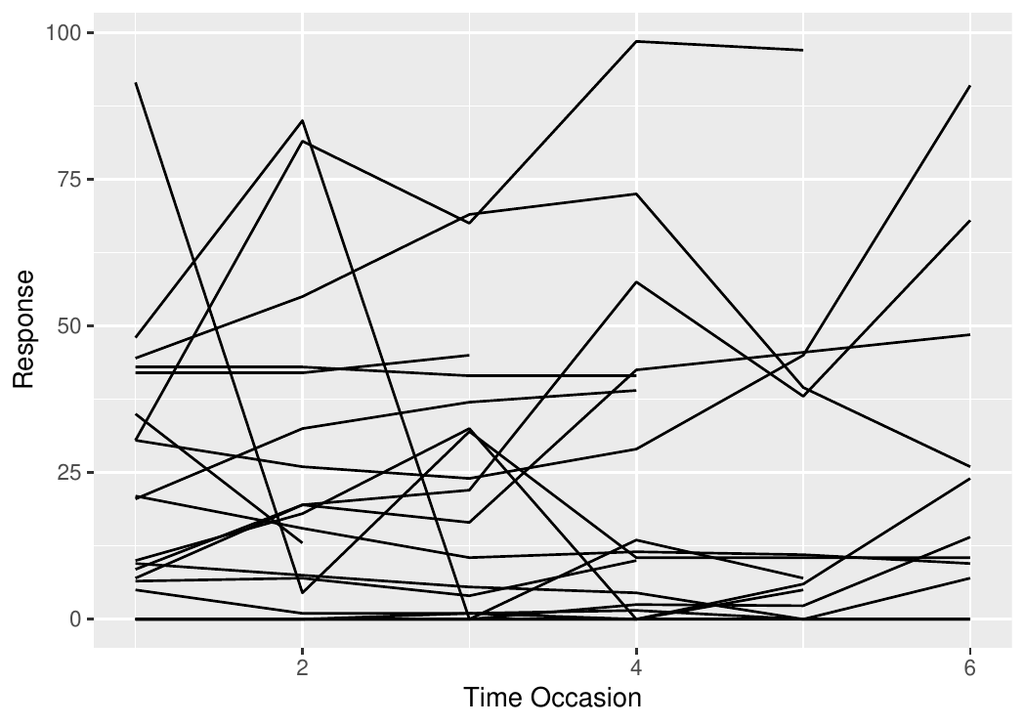

Figure 1: An example of longitudinal trajectories affected by both time-constant and time-varying unobserved heterogeneity

Let $\boldsymbol{\mathbf{x}}_{it}= (x_{it1}, \dots, x_{itp})^{\prime}$ indicate a $p$-dimensional vector of covariates associated with the parameters $\boldsymbol{\mathbf{\beta}}_{q} = (\beta_{1,q}, \dots, \beta_{p,q})^{\prime}$. Furthermore, let $\boldsymbol{\mathbf{z}}_{it} = (z_{it1}, \dots, z_{itd})^\prime$ and $\boldsymbol{\mathbf{w}}_{it} = (w_{it1}, \dots, w_{itl})^\prime$ denote two disjoint vectors of $d \ge 1$ and $l\geq 1$ explanatory variables (not included in $\boldsymbol{\mathbf{x}}_{it}$), respectively. The former is associated with the vector of unit- and quantile-specific random coefficients $\boldsymbol{\mathbf{b}}_{i,q}=(b_{i1,q}, \dots, b_{id,q})^\prime$ taking value in the set $\{\boldsymbol{\mathbf{\zeta}}_{1,q}, \dots, \boldsymbol{\mathbf{\zeta}}_{G_q,q}\}$ with probability $\pi_{g,q} = \Pr(\boldsymbol{\mathbf{b}}_{i,q} = \boldsymbol{\mathbf{\zeta}}_{g,q}), g = 1, \dots, G_q$. The latter is associated to the vector of unit-, time-, and quantile-specific random coefficients $\boldsymbol{\mathbf{\alpha}}_{it,q} = (\alpha_{it1,q}, \dots, \alpha_{itl,q})^\prime$, which evolves over time according to a homogeneous, first order, quantile-dependent, hidden Markov chain $\{S_{it, q}\}$. As before, this is defined over the finite state space $\mathcal{S}_q = \{1, \dots, m_q\}$ and is fully described by means of the initial probability vector $\boldsymbol{\mathbf{\delta}}_{q} = (\delta_{1,q, \dots, \delta_{m_q,q}})'$ and the transition probability matrix $\boldsymbol{\mathbf{\Gamma}}_{q}$, with generic element $\gamma_{s_{it,q} \mid s_{it-1,q},q}.$ The reader must note that, to ensure identifiability, the intercept term is included in either $\boldsymbol{\mathbf{z}}_{it}$ or $\boldsymbol{\mathbf{w}}_{it}$ (or in neither), but never in both. A similar principle applies to unit-specific, discrete, random slopes in the model, ensuring that $\boldsymbol{\mathbf{z}}_{it}$ and $\boldsymbol{\mathbf{w}}_{it}$ have no common elements. Further, random coefficients $\boldsymbol{{b}}_{i,q}$ and $\boldsymbol{\mathbf{\alpha}}_{it,q}$ are assumed to be independent.

For a given quantile level $q \in (0,1)$ and conditional on $\boldsymbol{\mathbf{b}}_{i,q} = \boldsymbol{\mathbf{\zeta}}_{g,q}$ and $\boldsymbol{\mathbf{\alpha}}_{it,q} = \boldsymbol{\mathbf{\alpha}}_{s_{it,q},q}$, longitudinal responses recorded from the same unit are assumed to be independent (local independence) and to follow an ALD with skewness, scale, and location parameter denoted by $q$, $\sigma_q$, and $\mu_{itgs_{it,q}, q}$, respectively. This latter parameter is defined by the following regression model:
$$\mu_{itgs_{it,q}, q} =
\boldsymbol{\mathbf{x}}_{it}^\prime \boldsymbol{\mathbf{\beta}}_q +
\boldsymbol{\mathbf{z}}_{it}^\prime \boldsymbol{\mathbf{\zeta}}_{g,q} +
\boldsymbol{\mathbf{w}}_{it}^\prime
\boldsymbol{\mathbf{\alpha}}_{s_{it,q},q}.$$
Based on such assumptions, the likelihood function is
$$L(\cdot \mid q) =
\prod_{i = 1}^{n} \sum_{g = 1}^{G_q} \sum_{s_{i1,q}=1}^{m_q}\cdots
\sum_{s_{iT_i,q}=1}^{m_q}
\left[\delta_{s_{i1,q},q} \prod_{t = 2}^{T_i} \gamma_{s_{it,q} \mid
s_{it-1,q},q}\right]
\left[\prod_{t = 1}^{T_i} f_{y \mid b,s}(y_{it} \mid
\boldsymbol{\mathbf{b}}_{i,q}
= \boldsymbol{\mathbf{\zeta}}_{g,q}, {s_{it,q}};q)\right] \pi_{g,q},$$
where, as before, $f_{y \mid b,s}(y_{it} \mid \boldsymbol{\mathbf{b}}_{i,q} = \boldsymbol{\mathbf{\zeta}}_{g,q}, {s_{it,q}};q)$ denotes the density of the ALD. In this framework, unobserved unit-specific features that remain constant over time are captured by the random coefficients $\boldsymbol{\mathbf{\zeta}}_{g,q}$; sudden temporal shocks in the unit-specific profiles, due to TV sources of unobserved heterogeneity, are captured instead by the random coefficients $\boldsymbol{\mathbf{\alpha}}_{s_{it,q},q}$.

To conclude this section, it is worth noticing that, when a single hidden state ($m_{q}=1$) is considered and $\boldsymbol{\mathbf{b}}_{i,q}= \boldsymbol{\mathbf{\zeta}}_{g,q}$, the location parameter $\mu_{itgs_{it,q},q}$ simplifies to $\mu_{itg,q}$ and the model reduces to the linear quantile mixture with TC random coefficients only. Also, when a single mixture component is considered ($G_{q} = 1$), the location parameter $\mu_{itgs_{it,q},q}$ simplifies to $\mu_{its_{it,q},q}$ and the model reduces to the dynamic finite mixture of linear quantile regressions with TV random coefficients only. Last, when both $G_{q}$ and $m_{q}$ are equal to 1, the model reduces to a standard linear quantile regression model without random coefficients. These properties make this latter specification more flexible and general than the alternatives described so far, at the cost of a higher computational complexity.

# Model estimation and inference

In this section, we describe the algorithm for ML estimation of model parameters in the linear quantile mixture models detailed in the previous section. We focus on the specification based on both TC and TV random coefficients, as the simpler alternatives based on TC or TV random coefficients only arise as special cases. We provide details of an EM algorithm for parameter estimation in Section 3.1; the procedure for deriving standard errors and choosing the optimal number of mixture components and/or states of the hidden Markov chain is described in Section 3.2.

## Maximum likelihood estimation

Let $\boldsymbol{\mathbf{\theta}}_{q}$ denote the global set of free model parameters for a given quantile level $q \in (0,1)$. To derive an estimate for such a vector, we may rely on indirect maximization of the likelihood function via an extended version of the EM algorithm (Dempster, Laird, and Rubin 1977). Let $u_{i,q}(g)$ and $v_{it,q}(h)$ be the indicator variables for $\boldsymbol{\mathbf{b}}_{i,q} = \boldsymbol{\mathbf{\zeta}}_{g,q}$ and $S_{it,q} = h$, respectively, and let $v_{it,q}(h,k) = v_{it-1,q}(h)\times v_{it,q}(k)$ denote the indicator variable for unit $i$ moving from state $h$ at occasion $t-1$ to state $k$ at occasion $t$, with $g = 1, \dots, G_{q},$ and $h, k = 1, \dots, m_{q}$. For a given $q \in (0,1)$, the EM algorithm starts from the following complete-data log-likelihood function:
$$\begin{aligned}
\label{eq:completeL}
\ell_c (\boldsymbol{\mathbf{\theta}}_{q} ) &=
\sum_{i= 1}^n \left\{
\left[ \sum_{g=1}^{G_q} u_{i,q}(g) \log \pi_{g,q}\right]
\right.\\\nonumber
&+
\left. \left[\sum_{h=1}^{m_q} v_{i1,q}(h)\log \delta_{h,q} +\sum_{t =
2}^{T_i} \sum_{h = 1}^{m_q} \sum_{k = 1}^{m_q} v_{it,q}(h,k) \log
\gamma_{k\mid h,q} \right] \right.\\\nonumber
&+
\left.\left[\sum_{t = 1}^{T_i} \sum_{g
=1}^{G_{q}}\sum_{h=1}^{m_{q}} u_{i,q}(g) v_{it,q}(h) \log f_{y \mid
b,s} (y_{it}\mid \boldsymbol{\mathbf{b}}_{i,q} =
\boldsymbol{\mathbf{\zeta}}_{g,q}, S_{it,q} = h)\right] \right\}.
\end{aligned} (\#eq:completeL)$$
At the $r$-th iteration, the E-step of the EM algorithm requires the computation of the expected value of the complete-data log-likelihood in Equation @ref(eq:completeL), conditional on the observed data $\boldsymbol{\mathbf{y}} = (\boldsymbol{\mathbf{y}}_1, \dots, \boldsymbol{\mathbf{y}}_n)^\prime$ and the current parameter estimates $\hat{\boldsymbol{\mathbf{\theta}}}_q^{(r-1)}$. That is, it requires the computation of
$$Q(\boldsymbol{\mathbf{\theta}}_q \mid
\hat{\boldsymbol{\mathbf{\theta}}}_q^{(r-1)}) =
\mathbb{E}\left[\ell_c(\boldsymbol{\mathbf{\theta}}_{q}) \mid
\boldsymbol{\mathbf{y}},
\hat{\boldsymbol{\mathbf{\theta}}}_q^{(r-1)}\right].$$
This means computing the posterior expectations of the indicator variables $u_{i,q}(g)$, $v_{it,q}(h)$, and $v_{it,q}(h,k)$. Regarding these two latter, a simplification is obtained by considering the forward and backward probabilities (Baum et al. 1970; Welch 2003) typically used in the hidden Markov model framework; see (Maria Francesca Marino, Tzavidis, and Alfò 2018) for further details. In the M-step of the algorithm, parameter estimates $\hat{\boldsymbol{\mathbf{\theta}}}_q$ are derived by maximizing $Q(\boldsymbol{\mathbf{\theta}}_q \mid \hat{\boldsymbol{\mathbf{\theta}}}_q^{(r-1)})$

The E- and the M-step are alternated until convergence, which is defined as the (relative) difference between two subsequent likelihood values being lower than a given threshold, $\varepsilon>0.$

## Standard errors and model selection

Following the standard procedure used in the quantile regression framework, standard errors for model parameter estimates are derived via a nonparametric bootstrap approach (see e.g., Buchinsky 1995). In detail, we employ a block-bootstrap procedure, where a re-sampling of the statistical units is performed and the corresponding sequence of observed measurements is retained to preserve within-unit dependence (Lahiri 1999).

Let $\hat{\boldsymbol{\mathbf{\theta}}}^{(r)}_{q}$ denote the vector of model parameter estimates obtained in the $r$-th bootstrap sample, $r = 1, \dots, R$. Estimates of the standard errors for the vector $\hat{\boldsymbol{\mathbf{\theta}}}_{q}$ correspond to the diagonal elements of the matrix
$$\widehat{ \textbf
V}(\hat{\boldsymbol{\mathbf{\theta}} }_{q}) =
\sqrt{\frac{1}{R} \sum_{r = 1}^{R} \left(
\hat{\boldsymbol{\mathbf{\theta}}}^{(r)}_{q} - \hat
{\boldsymbol{\mathbf{\theta}}}_{q} \right) \left(
\hat{\boldsymbol{\mathbf{\theta}}}^{(r)}_{q} - \hat
{\boldsymbol{\mathbf{\theta}}}_{q} \right)^{\prime}}.$$
A crucial point when dealing with finite mixtures is the choice of the number of components and/or hidden states. For a fixed quantile level $q$, a simple and frequently used solution is as follows. Parameter estimates are computed for varying combinations of the number of components and states, $[G_q,m_q]$; the model with the best fit, typically measured via log-likelihood or penalized likelihood criteria (such as AIC or BIC), is retained. However, given that these criteria may suffer from early stopping due to lack of progress rather than true convergence and the log-likelihood may present multiple local maxima, the EM algorithm is initialized from different starting points and the model corresponding to the highest likelihood value is retained before applying the penalization. In this regard, a deterministic start may be employed alongside a set of random start initializations. Specifically, the deterministic start is obtained by first estimating a linear regression model for the mean response using maximum likelihood, including all covariates – both those associated with fixed effects and those assumed to have a TC or TV random effect. The estimated fixed regression coefficients serve as initial values for the corresponding parameters. Initial values for TC and/or TV random coefficients are obtained by adding an appropriate constant to the corresponding fixed effect estimates from the homogeneous model. Prior component probabilities and/or initial probabilities for the latent Markov chain are set uniformly; transition probabilities $\gamma_{k \mid h,q}, \, k, h = 1, \dots, m_q$ are instead set to $(1 + w\mathbb I (k = h))/(m_q+ w)$, where $w$ is a proper tuning constant. Random starting points are generated by randomly perturbing the deterministic starting values.

While a multi-start strategy may mitigate the risk of local maxima, it is worth highlighting that the final solution may still lie on the boundary of the parameter space. This can lead to several issues such as (*i*) splitting components or latent states into multiple subgroups, (*ii*) convergence to (near-)identical parameter estimates across different components or hidden states; (*iii*) inflated standard errors; or (*iv*) instability in fixed-effect estimates. Therefore, it is strongly recommended to carefully examine the selected solution and prefer a simpler model (with a lower number of components and/or states) whenever there are indications of the above-mentioned issues. To conclude, note that the selection of the optimal number of components and/or states ($G_{q}$ and/or $m_{q}$) should be guided by the need of capturing the unobserved sources of heterogeneity characterizing the data. In this sense, the primary goal is that of providing a sufficiently accurate approximation of the true, possibly continuous, distribution of the random coefficients in the model, rather than identifying homogeneous clusters of units, as typically done within the finite mixture framework.

# The `lqmix` R package

In this section, we introduce the R package `lqmix`, developed to deal with linear quantile mixture models for longitudinal data. We illustrate the main functions for estimation and inference on the parameters of models described in the previous sections by considering the application to the labor pain benchmark dataset (Davis 1991). Details on this dataset are given in the following.

## Labor pain data

Firstly reported by (Davis 1991) and since then analyzed by (Jung 1996) and (Geraci and Bottai 2007) among others, labor pain data come from a randomized clinical trial aiming at analyzing the effectiveness of a medication for relieving labor pain in women. A total of $n=83$ women were randomized to a treatment/placebo group, and a response variable evaluating the self-reported amount of pain measured every $30$ minutes on a 100-$mm$ line was recorded. Here, 0 corresponds to absence of pain, while 100 corresponds to extreme pain. The number of available measurements per woman ranges from a minimum of 1 to a maximum of $T_i = 6, i = 1, \dots, n$. That is, we are in the presence of an unbalanced longitudinal design, for which a MAR assumption seems to be reasonable. A total of $\sum_{i=1}^{83} T_i = 357$ measurements is available.

Together with the outcome of interest (`meas`), two covariates are available: `trt` denotes an indicator variable identifying the group each woman is assigned to (1 = treatment, 0 = placebo), while `time` identifies the measurement occasion the response was recorded at. Data are stored in the data frame `pain` included in the `lqmix` package, as shown below.

```r
R> head(pain)
```

```r
  id meas trt time
1  1  0.0   1    1
2  1  0.0   1    2
3  2  0.0   1    1
4  2  0.0   1    2
5  2  0.0   1    3
6  2  2.5   1    4
```

Data are severely skewed, and skewness changes magnitude and sign over time. In Figure 2, we report some selected diagnostics for a linear mixed model based on TC, Gaussian, random intercepts, using `trt`, `time`, and their interaction (`trt:time`) as covariates. The model is estimated by means of the `lmer` function implemented in the `lme4` R package.

```r
R> outLME = lmer(meas ~ trt + time + trt:time + (1|id), data = pain)
R> par(mfrow = c(1,2))
R> qqnorm(residuals(outLME), main = "")
R> qqline(residuals(outLME))
R> qqnorm(unlist(ranef(outLME)$id), main = "")
R> qqline(unlist(ranef(outLME)$id))
```

In particular, Figure 2 reports the Normal probability plots for model residuals: the left panel shows unit- and time-specific residuals, while the right one shows the empirical Bayes estimates of unit-specific random intercepts. As itcan be easily noticed, both plots indicate the presence of potentially influential observations in the data, as well as the violation of the Gaussian assumption for the random intercepts in the model. Therefore, using linear quantile mixtures seems to be a reasonable choice for the analysis of such data.

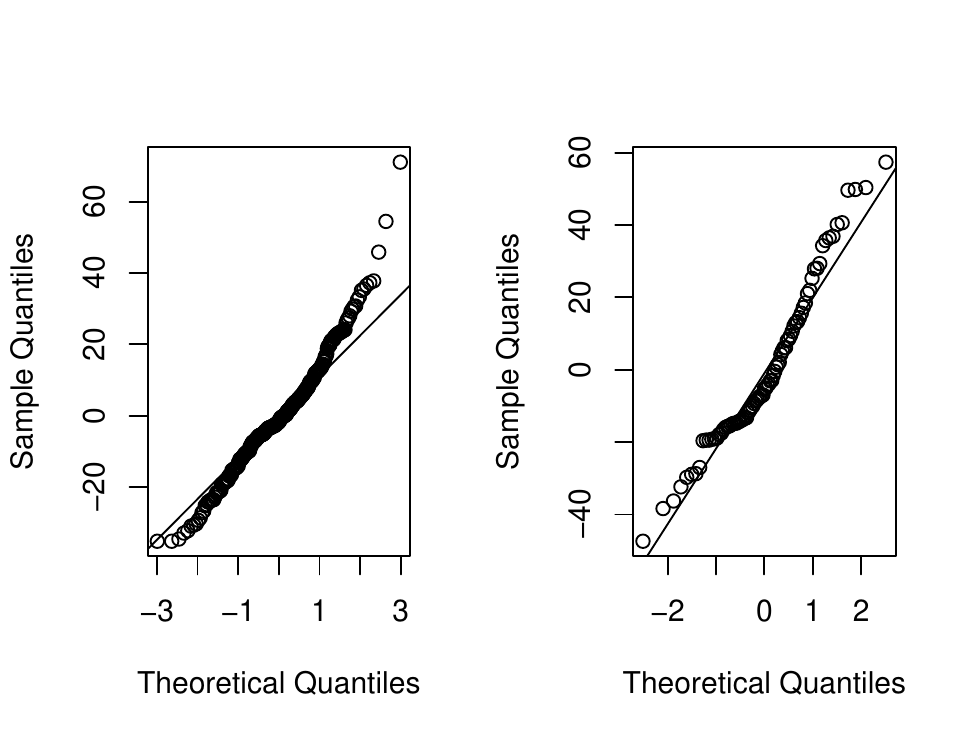

Figure 2: Labor pain data. Linear mixed effect model with Gaussian random intercepts. Normal probability plot for unit- and time-specific residuals (left plot) and for empirical Bayes estimates of unit-specific intercepts (right plot).

## The `lqmix` function

The main function implemented in the `lqmix` R package is `lqmix`. It allows for the estimation of the parameters of a linear quantile mixture based on either TC, TV, or both types of discrete random coefficients. The input arguments can be displayed on the R console as follows:

```r
R> args(lqmix)
```

```r
function (formula, randomTC = NULL, randomTV = NULL, group, time, G = NULL, m = NULL, data,
  qtl = 0.5, eps = 10^-5, maxit = 1000, se = TRUE, R = 200, start = 0,
  parInit = list(betaf = NULL, betarTC =  NULL, betarTV = NULL, pg = NULL,
  delta = NULL, Gamma = NULL, scale = NULL),
  verbose = TRUE, seed = NULL, parallel = FALSE, ncores = 2)
```

The first mandatory argument, `formula`, denotes a two-side formula of the type `(resp`$\sim$`Fexpr)`, where `resp` is the response variable and `Fexpr` is an expression determining the fixed-coefficient vector, $\boldsymbol{\mathbf{x}}_{it}$. On the other side, `randomTC` and `randomTV` are two one-side formulas of the type `(`$\sim$`Rexpr1)` and `(`$\sim$`Rexpr2)`, where `Rexpr1` and `Rexpr2` identify the columns of covariates associated with TC and TV random-coefficient vectors, $\boldsymbol{\mathbf{z}}_{it}$ and $\boldsymbol{\mathbf{w}}_{it}$, respectively. Note that both these arguments are optional, so that the user may decide to estimate a linear quantile regression model with either TC or TV random coefficients, or with a combination of them. Further, variables reported in `Rexpr1` and `Rexpr2` must not overlap and, if any of them appears also in the fixed effect formula (`formula`), the corresponding parameter is estimated as a TC/TV random coefficient only. The arguments `group` and `time` are strings indicating the grouping and time variable, respectively. All such variables are taken from the data frame specified through the (mandatory) argument `data`. The arguments `G` and `m` are used to specify the number of mixture components and/or hidden states in the model, respectively, while `qtl` allows to specify the quantile level (by default, `qtl = 0.5`). The arguments `se`, `R`, and `start` allow to specify whether block-bootstrap standard errors should be computed (by default, `se = TRUE`), the number of bootstrap samples to be used for this purpose (by default, `R = 200`), and the initialization rule to consider. As regards this latter, three possible specifications are allowed: `start = 0` is used for a deterministic start of model parameters (the default option); `start = 1` is used for a random start of model parameters; `start = 2` is used to consider a starting rule based on given model parameters specified via the `parInit` list argument. The arguments `maxit`, `eps`, and `verbose` identify the maximum number of iterations for the EM algorithm (by default, `maxit = 1000`), the corresponding tolerance level (by default `eps =`$\mathtt{10^{-5}}$), and whether output should be printed (by default, `verbose = TRUE`), respectively. As for the `seed` argument, this is devoted to setting a seed for random number generation that is used for the random starting rule (`start=1`) described so far and for computing parameters’ standard errors. The arguments `parallel` and `ncores` control parallel computing when standard errors are requested, with `ncores` defaulting to 2.

### Estimating linear quantile mixtures with TC random coefficients

To explore features of the `lqmix` function, we start by considering a two-component linear quantile mixture ($\mathtt{G_{q} = 2}$) for the median ($\mathtt{qtl = 0.5}$) with a TC random intercept for the analysis of the pain data. This is estimated as follows:

```r
R> outTC = lqmix(formula = meas ~ time + trt + trt:time, randomTC = ~1, time = "time",
  group = "id", G = 2, data = pain)
```

```r
--------|-------|-------|--------|-------------|-------------|
  model |  qtl  |   G   |  iter  |      lk     |   (lk-lko)  |
--------|-------|-------|--------|-------------|-------------|
     TC |   0.5 |     2 |      0 |    -1682.31 |          NA |
     TC |   0.5 |     2 |      8 |    -1607.11 | 4.64719e-06 |
--------|-------|-------|--------|-------------|-------------|
Computing standard errors ...
  |========================================================================| 100%
```

The running time for the above command is 5.212 seconds when run on an Apple M1 architecture (16GB, MacOS: Sequoia 15.6.1). This represents the architecture used for all the codes illustrated in the paper. In the following, we report the output of the above call to `lqmix`, which is an object of class `lqmix`, obtained by using the `print` method of the `S3` class.

```r
R> outTC
```

```r
Model: TC random coefficients with G=2 at qtl=0.5
******************************************************

---- Observed process ----

Fixed Coefficients:
    time      trt time.trt
 11.6669  -2.1659 -10.8335

Time-Constant Random Coefficients:
      (Intercept)
Comp1      1.3325
Comp2     43.3325

Residual scale parameter: 7.3289 - Residual standard deviation: 20.7294

---- Latent process ----

Mixture probabilities:
 Comp1  Comp2
0.6737 0.3263

Log-likelihood at convergence: -1607.11
Number of observations: 357 - Number of subjects: 83
```

Looking at the output, we may recognize two separate sections, reporting estimates for the observed and the latent process, respectively. As regards the observed process, the estimated fixed coefficients suggest how self-reported pain increases as time passes by, together with a positive effect of the treatment under investigation (negative sign for the `trt` variable), with benefits that increase with time. On the other side, the estimated random coefficients highlight the presence of two well-separated groups of women, reporting a low and a medium pain at the baseline, respectively. In the last part, the estimated scale parameter and the corresponding error standard deviation are shown. This latter corresponds to the standard deviation of an ALD. As regards the latent process, estimates highlight that 67.37% of women belong to the first mixture component (low-pain level); the remaining 32.63% belong to the second one (medium-pain level). All estimated parameters are stored in the object `outTC` as `betaf` (the fixed coefficients), `betarTC` (the TC random coefficients), `scale` (the scale parameter), `sigma.e` (the conditional standard deviation of responses), and `pg` (the component prior probabilities). Further, when leaving the statement `se = TRUE` (default value), the `outTC` object also contains information on the estimated standard errors of model parameters obtained via the bootstrap procedure detailed in Section “*Standard Errors and model selection*”. These standard errors can be accessed by prefixing the corresponding parameter names with `se.`, as listed above.

The following information is also stored in the the `outTC` object: the log-likelihood value at convergence (`lk`), the number of model parameters (`npar`), the values of AIC and BIC (`aic` and `bic`), the quantile level (`qtl`), the number of mixture components (`G`), the total number of subjects and observations (`nsbjs` and `nobs`), the mixture components’ posterior probabilities obtained at convergence of the EM algorithm (`postTC`), the bootstrap variance-covariance matrices of the regression coefficients (`vcov`), the type of missingness data is assumed to be affected by (`miss`), the estimated model (`model`), and the model call (`call`). Last, model matrices associated with fixed and TC random coefficients are stored in the `outTC` object as `mmf` and `mmrTC`, respectively.

### Estimating linear quantile mixtures with TV random coefficients

The same `lqmix` function can be used to obtain parameter estimates for a quantile mixture with TV random coefficients. To analyze the labor pain data, we consider a linear quantile mixture for the median ($\mathtt{qtl = 0.5}$), with a TV random intercept defined over a two-state latent space ($\mathtt{m_{q} = 2}$).

```r
R> outTV = lqmix(formula = meas ~ time + trt + trt:time, randomTV = ~1, time = "time",
  group = "id", m = 2, data = pain)
```

```r
--------|-------|-------|--------|-------------|-------------|
  model |  qtl  |   m   |  iter  |      lk     |   (lk-lko)  |
--------|-------|-------|--------|-------------|-------------|
     TV |   0.5 |     2 |      0 |    -1688.99 |          NA |
     TV |   0.5 |     2 |     10 |    -1576.61 |    0.366345 |
     TV |   0.5 |     2 |     20 |    -1575.79 | 9.32048e-05 |
     TV |   0.5 |     2 |     29 |    -1575.79 | 9.43243e-06 |
--------|-------|-------|--------|-------------|-------------|
Computing standard errors ...
  |======================================================================| 100%
```

The running time for obtaining results is 11.285 seconds. The output is given below.

```r
R> outTV
```

```r
Model: TV random coefficients with m=2 at qtl=0.5
******************************************************

---- Observed process ----

Fixed Coefficients:
    time      trt time.trt
  6.5012  -0.4923  -6.0013

Time-Varying Random Coefficients:
    (Intercept)
St1      0.4924
St2     60.9926

Residual scale parameter: 5.8337 - Residual standard deviation: 16.5003

---- Latent process ----

Initial probabilities:
   St1    St2
0.7667 0.2333

Transition probabilities:
         toSt1  toSt2
fromSt1 0.8883 0.1117
fromSt2 0.0271 0.9729

Log-likelihood at convergence: -1575.795
Number of observations: 357 - Number of subjects: 83
```

Results for the observed process allow us to derive similar conclusions to those detailed in the previous section, even though the magnitude of the effects is reduced. As regards the latent layer of the model, the `print` method shows the estimates for the initial and the transition probabilities of the hidden Markov chain. Based on such estimates, one may conclude that 76.67% of women start in the first hidden state which, based on the estimated time-varying random intercepts, is characterized by a low pain level. The remaining 23.33% of women start the study with an intermediate baseline pain level. Looking at the estimated transition probabilities, we may notice that, regardless of the treatment effect, labor pain tends to increase as time passes by, with women being in the *low pain* state moving towards the *medium pain* state with probability equal to $0.1117$. Estimated parameters are stored in the object `outTV` as `betaf` (the fixed coefficients), `betarTV` (the TV random coefficients), `scale` (the scale parameter), `sigma.e` (the conditional standard deviation of responses derived from an ALD with parameters `scale` and `qtl`), `delta` (the initial probability vector), and `Gamma` (the transition probability matrix). As detailed in the previous section, bootstrap standard errors are stored by using the prefix “`se.`” to the names of parameters of interest. Last, posterior probabilities for the latent states of the hidden Markov chain and the model matrix for the TV random coefficients are stored as `posTV` and `mmrTV`, respectively, in the `outTV` object.

### Estimating linear quantile mixtures with TC and TV random coefficients

When specifying both the `randomTC` and the `randomTV` formulas, and therefore both `G` and `m`, the `lqmix` function allows for the estimation of linear quantile mixtures based on both TC and TV, discrete, random coefficients. To analyze labor pain data, we consider a linear quantile mixture for the median (`qtl = 0.5`), with a TV random intercept, based on $m_{q} = 2$ hidden states, and a TC random slope for the `time` variable, based on $G_{q} = 2$ components. To estimate such a model and consider a random start initialization (`start=1`), the following command can be run:

```r
R> outTCTV = lqmix(formula = meas ~ trt + time + trt:time, randomTC = ~ time, randomTV = ~1,
  time = "time", group = "id", m = 2, G = 2, data = pain, se = FALSE, start = 1, seed = 10)
```

```r
--------|-------|-------|-------|--------|-------------|-------------|
  model |  qtl  |   m   |   G   |  iter  |      lk     |   (lk-lko)  |
--------|-------|-------|-------|--------|-------------|-------------|
   TCTV |   0.5 |     2 |     2 |      0 |    -1723.86 |          NA |
   TCTV |   0.5 |     2 |     2 |     10 |    -1594.61 |     14.8135 |
   TCTV |   0.5 |     2 |     2 |     20 |    -1554.41 |     3.47302 |
   TCTV |   0.5 |     2 |     2 |     30 |    -1541.16 |    0.165982 |
   TCTV |   0.5 |     2 |     2 |     37 |    -1541.12 | 2.98304e-06 |
--------|-------|-------|-------|--------|-------------|-------------|
```

This requires a running time of 11.461 seconds. The output of the above call to `lqmix`, obtained through the `print` method of the `S3` class, is reported below.

```r
R> outTCTV
```

```r
Model: TC and TV random coefficients with m=2 and G=2 at qtl=0.5
******************************************************************

---- Observed process ----

Fixed Coefficients:
     trt trt.time
 -9.2859  -5.0428

Time-Constant Random Coefficients:
         time
Comp1  5.5428
Comp2 14.9178

Time-Varying Random Coefficients:
    (Intercept)
St1      8.7859
St2     69.7859

Residual scale parameter: 5.1259 - Residual standard deviation: 14.4983

---- Latent process ----

Mixture probabilities:
 Comp1  Comp2
0.7381 0.2619

Initial probabilities:
   St1    St2
0.8036 0.1964

Transition probabilities:
         toSt1  toSt2
fromSt1 0.9641 0.0359
fromSt2 0.0434 0.9566

Log-likelihood at convergence: -1541.12
Number of observations: 357 - Number of subjects: 83
```

As it is clear from the output, the linear quantile mixture with both TC and TV discrete random coefficients produces more detailed information when compared to those discussed so far. Also in this case, we may recognize in the output the two sections entailing the observed and the latent process, respectively. In the former, estimates for the fixed, TC, and TV random coefficients are reported. For the latent part, the output reports information on the mixture, the initial, and the transition probabilities.

By looking at the results, we conclude again that self-reported pain is lower for women under medication (negative sign for the `trt` variable) and that benefits increase with time. Looking at the estimated TC random coefficients and the corresponding prior probabilities, we may distinguish two well separated groups of women. They exhibit different trends in pain levels over time: 73.81% experience a mild increase in pain levels, whereas 26.19% show a steeper increase. On the other side, the estimated TV random coefficients identify two groups of women characterized by a low and a medium baseline labor pain level, respectively. At the beginning of the observation period, 80.36% of women belong to the first group, while the remaining 19.64% to the second. By looking at the estimated transition probability matrix, we conclude that the group composition remains largely unchanged over time once controlling for the other effects in the model ($\gamma_{hh,0.5}>0.95, h = 1, 2$).

Estimated parameters are stored in the object `outTCTV`. Now both those related to the TC finite mixture as well as those related to the hidden Markov chain are referenced. In detail, `outTCTV` contains `betaf` (the fixed coefficients), `betarTC` (the TC random coefficients), `betarTV` (the TV random coefficients), `scale` (the scale parameter), `sigma.e` (the conditional standard deviation of responses derived from an ALD with parameters `scale` and `qtl`), `pg` (the component prior probabilities), `delta` (the initial probabilities), and `Gamma` (the transition probabilities). Standard errors (if computed), as well as additional information on the data, the estimated model, posterior probabilities, and model matrices are stored in the `outTCTV` object.

## The `search_lqmix` function for model selection

As described in Section “*Standard errors and model selection*”, the number of mixture components $G_q$ and the number of hidden states $m_q$ in the model are unknown quantities that need to be estimated. Moreover, a multi-start strategy is frequently needed to solve, at least partially, the potential multimodality of the likelihood surface. Both issues can be addressed by means of the `search_lqmix()` function. Input arguments and corresponding default values can be displayed on the R console though the `args` function:

```r
R> args(search_lqmix)
```

```r
function (formula, randomTC = NULL, randomTV = NULL, group, time, Gv = NULL, mv = NULL, data,
  method = "bic", nran = 0, qtl = 0.5, eps = 10^-5, maxit = 1000, se = TRUE, R = 200,
  verbose = TRUE, seed = NULL, parallel = FALSE, ncores = 2)
```

Most of the arguments of this function correspond to those described so far. The remaining ones are specified as follows. `Gv` and `mv` denote vectors identifying the range for the number of mixture components, $G_q$, and the number of hidden states, $m_q$, to be considered, respectively, for a fixed quantile level $q \in (0,1)$. When both arguments are specified, the search of the optimal linear quantile mixture with TC and TV random coefficients is performed. When only one out the two arguments is specified, a linear quantile mixture based on either TC or TV random coefficients is estimated. A linear quantile regression with no random coefficients is also estimated either when both `mv` and/or `Gv` include the value 1, or when `Gv` includes 1 and `mv = NULL`, or when `mv` includes 1 and `Gv = NULL`. In this case, the function `lqr()` implemented in the `lqmix` R package and described in the following is employed.

The argument `method` is used for model selection purposes. One of three possible values is admitted: “`bic`” (by default), “`aic`”, or “`lk`”. The former two identify the optimal model as that providing the minimum value of the BIC or the AIC index, respectively. The latter, selects the optimal model as the one corresponding to the maximum log-likelihood value.

The argument `nran` specifies the number of random starts to be considered for each value in the range identified by `Gv` and `mv`. This number is strictly related to the type of model for which the optimal search is performed. In detail, following a similar strategy as that suggested by (Bartolucci, Pandolfi, and Pennoni 2017) for the `LMest` R package, when a linear quantile mixture based on TC random coefficients only is considered, the number of random initializations is set equal to $\mathtt{nran\times(G_q-1)}$; when only TV random coefficients are allowed, the number of random initializations is set equal to $\mathtt{nran\times(m_q-1)}$; last, when both TC and TV random coefficients are considered, the number of random initializations is set equal to $\mathtt{nran\times(G_q-1)\times(m_q-1)}$. By default, $\mathtt{nran = 0}$, so that no random initializations are considered. The `seed` argument is used to fix a seed and ensure reproducibility of results when the multi-start strategy based on random initializations is considered to estimate model parameters, as well as for deriving standard errors (when requested). Last, `parallel` and `ncores` are used for parallel computing of the standard errors.

We report below the results of the model selection strategy applied to the `pain` data, when focusing on a linear quantile mixture with a TV random intercept and a TC random slope associated to the variable `time`, for the quantile level $q = 0.5$. The search is done by looking for the optimal number of components ($G_{q}$) and hidden states ($m_{q}$), both in the set $\{1,2 \}$, by setting $\mathtt{nran = 50}$. The optimal model is selected according to the BIC index.

```r
R> sTCTV = search_lqmix(formula = meas ~ trt + time + trt:time, randomTC = ~time,
  randomTV = ~1, group = "id", time = "time", nran = 50, mv = 1:2, Gv = 1:2,
  data = pain, seed = 10)
```

```r
Search the optimal linear quantile mixture model
*************************************************
Random start: 0 ...
--------|-------|--------|-------------|
  model |  qtl  |  iter  |      lk     |
--------|-------|--------|-------------|
    HOM |   0.5 |      0 |    -1707.73 |
--------|-------|--------|-------------|
Random start: 0 ... 1  ... 2  ... 3  ... 4  ... 5  ... 6  ... 7  ... 8  ... 9  ... 10  ... 11  ... 12  ... 13  ... 14  ... 15  ... 16  ... 17  ... 18  ... 19  ... 20  ... 21  ... 22  ... 23  ... 24  ... 25  ... 26  ... 27  ... 28  ... 29  ... 30  ... 31  ... 32  ... 33  ... 34  ... 35  ... 36  ... 37  ... 38  ... 39  ... 40  ... 41  ... 42  ... 43  ... 44  ... 45  ... 46  ... 47  ... 48  ... 49  ... 50  ...
--------|-------|-------|--------|-------------|-------------|
  model |  qtl  |   G   |  iter  |      lk     |   (lk-lko)  |
--------|-------|-------|--------|-------------|-------------|
     TC |   0.5 |     2 |      0 |    -1626.59 |          NA |
     TC |   0.5 |     2 |      1 |    -1626.59 | 6.65801e-07 |
--------|-------|-------|--------|-------------|-------------|
Random start: 0 ... 1  ... 2  ... 3  ... 4  ... 5  ... 6  ... 7  ... 8  ... 9  ... 10  ... 11  ... 12  ... 13  ... 14  ... 15  ... 16  ... 17  ... 18  ... 19  ... 20  ... 21  ... 22  ... 23  ... 24  ... 25  ... 26  ... 27  ... 28  ... 29  ... 30  ... 31  ... 32  ... 33  ... 34  ... 35  ... 36  ... 37  ... 38  ... 39  ... 40  ... 41  ... 42  ... 43  ... 44  ... 45  ... 46  ... 47  ... 48  ... 49  ... 50  ...
--------|-------|-------|--------|-------------|-------------|
  model |  qtl  |   G   |  iter  |      lk     |   (lk-lko)  |
--------|-------|-------|--------|-------------|-------------|
     TV |   0.5 |     2 |      0 |    -1575.79 |          NA |
     TV |   0.5 |     2 |      4 |    -1575.79 | 8.79175e-06 |
--------|-------|-------|--------|-------------|-------------|
Random start: 0 ... 1  ... 2  ... 3  ... 4  ... 5  ... 6  ... 7  ... 8  ... 9  ... 10  ... 11  ... 12  ... 13  ... 14  ... 15  ... 16  ... 17  ... 18  ... 19  ... 20  ... 21  ... 22  ... 23  ... 24  ... 25  ... 26  ... 27  ... 28  ... 29  ... 30  ... 31  ... 32  ... 33  ... 34  ... 35  ... 36  ... 37  ... 38  ... 39  ... 40  ... 41  ... 42  ... 43  ... 44  ... 45  ... 46  ... 47  ... 48  ... 49  ... 50  ...
--------|-------|-------|-------|--------|-------------|-------------|
  model |  qtl  |   m   |   G   |  iter  |      lk     |   (lk-lko)  |
--------|-------|-------|-------|--------|-------------|-------------|
   TCTV |   0.5 |     2 |     2 |      0 |    -1538.76 |          NA |
   TCTV |   0.5 |     2 |     2 |      3 |    -1538.76 | 8.36816e-06 |
--------|-------|-------|-------|--------|-------------|-------------|
Computing standard errors for the optimal model...
  |===========================================================================| 100%
```

The running time for the above command is 33.332 seconds and the output is stored in the `sTCTV` object. This can be shown by means of the `print` method of the class `S3` as follows:

```r
R>  sTCTV
```

```r
Opt model: TC and TV random coefficients with m=2 and G=2 at qtl=0.5
*********************************************************************

---- Observed process ----

Fixed Coefficients:
     trt trt.time
 -4.3237  -5.0294

Time-Constant Random Coefficients:
         time
Comp1  5.3294
Comp2 15.6627

Time-Varying Random Coefficients:
    (Intercept)
St1      4.0237
St2     49.1746

Residual scale parameter: 4.7858 - Residual standard deviation: 13.5363

---- Latent process ----

Mixture probabilities:
 Comp1  Comp2
0.6351 0.3649

Initial probabilities:
   St1    St2
0.7553 0.2447

Transition probabilities:
         toSt1  toSt2
fromSt1 0.9552 0.0448
fromSt2 0.1497 0.8503

Log-likelihood at convergence: -1538.76
Number of observations: 357 - Number of subjects: 83
```

As reported in the first output line, the optimal model for the median (`qtl = 0.50`) according to the BIC criterion (the default option) is based on $G_{q} = 2$ mixture components and $m_{q} = 2$ hidden states. Results we obtain are in line with those reported in the previous section. Differences are due to the model selection strategy that aims at identifying the global maximum of the likelihood function.

To provide further insights into the analysis of the `pain` data and look at the potential of the `lqmix R` package, we also search for the optimal model for a different quantile level. Specifically, we apply the `search_lqmix` function for `qtl = 0.75` to study the impact of observed covariates on higher pain levels. When looking at the results reported below, we may notice that again the optimal specification (according to the BIC criterion) is obtained for $G_{q}=2$ and $m_{q} = 2$. Further, pain levels are lower when medication is taken, even though the estimated effect is lower than before. This result claims a lower beneficial effect of treatment for those women reporting higher pain levels. Comparing the estimated TC random coefficients for `qlt = 0.75` to those from the model for `qtl = 0.50`, we observe now a more pronounced increase of pain levels over time. The estimated TV random coefficients identify instead two groups of women declaring again a low and a medium baseline pain level, respectively. Baseline estimates, as expected, are now higher than those obtained for `qtl = 0.50`. The estimated transition probability matrix highlights a very high persistence in each of the two states; this means that baseline levels remain pretty constant over time.

```r
R> sTCTV75 = search_lqmix(formula = meas ~ trt + time + trt:time, randomTC = ~time,
                     randomTV = ~1, nran = 50, group = "id", time = "time", mv = 1:2,
                     Gv = 1:2, data = pain, seed = 10, qtl = 0.75)
```

```r
R> sTCTV75
```

```r
Opt model: TC and TV random coefficients with m=2 and G=2 at qtl=0.75
*********************************************************************

---- Observed process ----

Fixed Coefficients:
     trt trt.time
 -1.0538  -7.6027

Time-Constant Random Coefficients:
         time
Comp1  8.5027
Comp2 17.9231

Time-Varying Random Coefficients:
    (Intercept)
St1      5.1538
St2     65.9891

Residual scale parameter: 4.2329 - Residual standard deviation: 17.8476

---- Latent process ----

Mixture probabilities:
 Comp1  Comp2
0.6965 0.3035

Initial probabilities:
   St1    St2
0.7393 0.2607

Transition probabilities:
         toSt1  toSt2
fromSt1 0.9761 0.0239
fromSt2 0.0526 0.9474

Log-likelihood at convergence: -1577.189
Number of observations: 357 - Number of subjects: 83
```

## The `summary` method for `lqmix` and `search_lqmix` objects

The `summary` method, when applied to objects of class `lqmix` or `search_lqmix`, generates a summary object that allows for inference on model parameters. For `search_lqmix` objects, it returns the summary of the optimal model. In the following, we present the output of the `summary` method for the `sTCTV` object described so far.

```r
R> summary(sTCTV)
```

```r
Opt model: TC and TV random coefficients with m=2 and G=2 at qtl=0.5
***************************************************************************

---- Observed process ----

Fixed Coefficients:
         Estimate St.Error z.value P(>|z|)
trt       -4.3237   2.6423 -1.6363  0.0997 .
trt.time  -5.0294   0.7494 -6.7108  <2e-16 ***

Time-Constant Random Coefficients:
           Estimate St.Error z.value   P(>|z|)
time_Comp1   5.3294   0.5207  10.236 < 2.2e-16 ***
time_Comp2  15.6627   0.8050  19.457 < 2.2e-16 ***

Time-Varying Random Coefficients:
                Estimate St.Error z.value P(>|z|)
(Intercept)_St1   4.0237   1.6985   2.369  0.0175 *
(Intercept)_St2  49.1746   4.8451  10.149  <2e-16 ***
---
Signif. codes:  0 ‘***’ 0.001 ‘**’ 0.01 ‘*’ 0.05 ‘.’ 0.1 ‘ ’ 1

Residual scale parameter: 4.7858 - Residual standard deviation: 13.5363

---- Latent process ----

Mixture probabilities:
      Estimate St.Error
Comp1   0.6351   0.0668
Comp2   0.3649   0.0668

Initial probabilities:
    Estimate St.Error
St1   0.7553   0.0507
St2   0.2447   0.0507

Transition probabilities:
             Estimate St.Error
fromSt1toSt1   0.9552   0.0181
fromSt1toSt2   0.0448   0.0181
fromSt2toSt1   0.1497   0.0546
fromSt2toSt2   0.8503   0.0546

Log-likelihood at convergence: -1538.76
Number of observations: 357 - Number of subjects: 83
```

As before, two different sections may be distinguished. In the former, estimates, standard errors, test statistics, and corresponding approximate p-values for assessing significance of model parameters for the observed process are reported. This information is completed with the estimates of the scale parameter and the conditional standard deviation of the error terms. In the latter section of the output, estimates and standard errors for the parameters characterizing the latent layer of the model are reported.

# Other methods for `lqmix` and `search_lqmix` objects

Further methods implemented in the package are `predict`, `residuals`, and `vcov`. The former two return the conditional predicted values and the conditional residuals, given the component membership and/or the state occupied at a given occasion by units in the sample; `vcov` returns instead the variance-covariance matrix of fixed model parameters obtained from the block-bootstrap procedure detailed above.

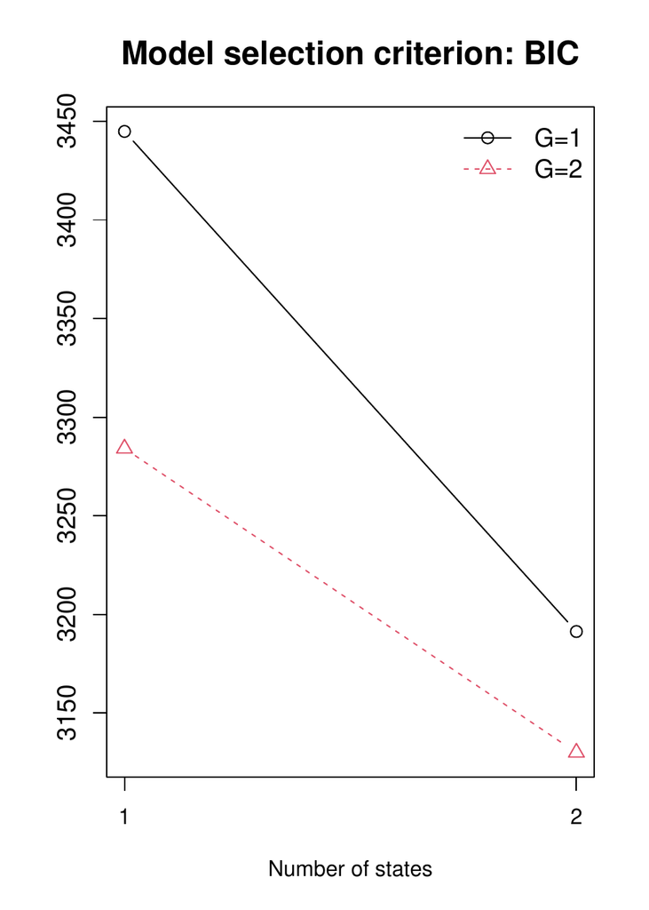

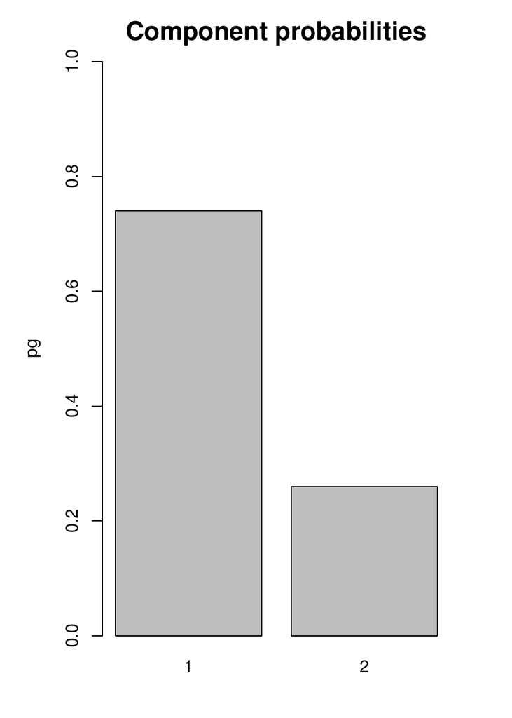

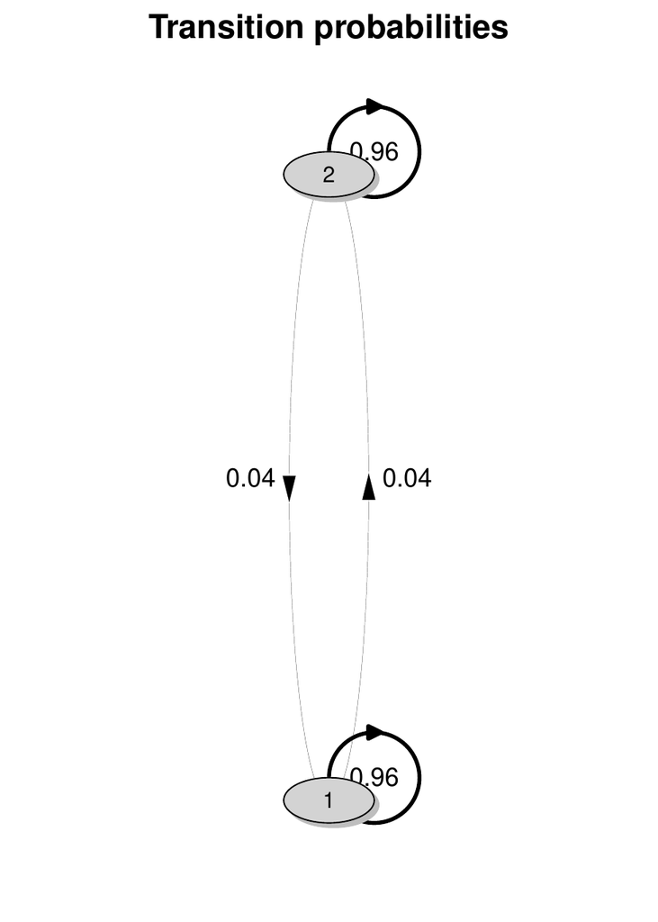

Figure 3: Results from the `plot` method

# Linear quantile regression for independent data

The package `lqmix` is thought for dealing with longitudinal data. However, it also implements the function `lqr()` for estimating a homogeneous linear quantile regression model via a ML approach. This is obtained by exploiting the parallelism between the ALD and the asymmetric quantile loss function. Input arguments for the `lqr` function and corresponding default values are as follows:

```r
R> args(lqr)
```

```r
function (formula, data, qtl = 0.5, se = TRUE, R = 100, verbose = TRUE, seed = NULL,
  parallel = FALSE, ncores = 2)
```

# Conclusions

Quantile regression is a fundamental tool of analysis when (*i*) the response distribution is skewed, (*ii*) outlying values are present, (*iii*) interest entails both the center and the tails of the response distribution. When dealing with longitudinal data, dependence between observations from the same unit must be properly considered to avoid biased inference. Thus, linear quantile regression models with unit-specific random coefficients may be effectively employed.

In this paper, we present the `lqmix` R package to estimate mixtures of linear quantile regression models for continuous longitudinal data, possibly affected by random missingness. Strong and unverifiable parametric assumptions on the random coefficients are avoided by considering a finite mixture specification. Either TC or TV random coefficients, or a combination of both, can be fitted to deal with different sources of unobserved heterogeneity affecting the longitudinal process. That is, the package allows us to deal with unit-specific unobserved features (omitted covariates in the model) which may vary and/or stay constant over the observational period, while looking at the quantiles of the conditional response variable.

Three main functions are implemented in the package. A first one, `lqmix`, allows the estimation of the different model specifications obtained by considering TC or TV random coefficients only, or a combination of them. A second function, `search_lqmix`, allows for the searching of the optimal model specification, based on various model selection criteria. A third function, `lqr`, is devoted to the estimation of linear quantile regression models for cross-sectional data. For a concise understanding, we report in Table 1 a description of the main parameters required by such functions.

(#tab:T1) Description of the main arguments for the functions `lqmix`, `search_lqmix`, and `lqr`.

| Arguments | Description | `lqmix` | `search_lqmix` | `lqr` |
| --- | --- | --- | --- | --- |
| `formula` | an object of class `formula`: a symbolic description of the model to be fitted of the form `resp`$\sim$`Fexpr` | yes | yes | yes |
| `randomTC` | a one-sided formula of the form $\sim z_{1}+z_{2}+...+z_{r}$ | yes | yes | no |
| `randomTV` | a one-sided formula of the form $\sim w_{1}+w_{2}+...+w_{l}$ | yes | yes | no |
| `group` | a string indicating the grouping variable | yes | yes | no |
| `time` | a string indicating the time variable | yes | yes | no |
| `G` | number of mixture components associated to TC random coefficients | yes | no | no |
| `m` | number of states associated to the TV random coefficients | yes | no | no |
| `Gv` | vector of possible number of mixture components associated to TC random coefficients | no | yes | no |
| `mv` | vector of possible number of states associated to TV random coefficients | no | yes | no |
| `data` | a data frame containing the variables named in `formula`, `randomTC`, `randomTV`, `group`, and `time` | yes | yes | yes |
| `qtl` | quantile to be estimated | yes | yes | yes |
| `eps` | tolerance level for (relative) convergence of the EM algorithm | yes | yes | no |
| `maxit` | maximum number of iterations for the EM algorithm | yes | yes | no |
| `se` | standard error computation for the optimal model | yes | yes | yes |
| `R` | number of bootstrap samples for computing standard errors | yes | yes | yes |
| `nran` | number of repetitions of each random initialization | no | yes | no |

When looking at the scalability of `lqmix`, the computational effort increases with the complexity of the model. Linear quantile mixtures of quantile regressions with TC random coefficients are computationally less demanding than those with TV random coefficients, which in turn are more efficient than models incorporating both TC and TV random terms. Additional factors influencing computational load include the number of repeated measures and, most significantly, the number of units in the sample. In our experience, `lqmix` easily handles datasets of small to moderate size (about 10 thousand units). For larger datasets, the computational effort increases, particularly in the estimation of standard errors. In this respect, parallel computing proves beneficial in managing computation times and maintaining performance.

Another aspect that is important to highlight entails the selection of the number of bootstrap samples to consider for the estimation of the standard errors, $R$. Practitioners are always recommended to set `R` to the value that ensures the stability of results, bearing in mind that the higher the model complexity the larger $R$ is expected to be.

Further updates of the package will include the possibility to deal with multivariate responses in the spirit of (Alfò et al. 2021). Here, outcome-specific random coefficients are considered to model the unobserved heterogeneity characterizing each response variable. The corresponding multivariate distribution is left unspecified and estimated directly from the data. This proposal can be extended to the TV setting, as well as to the mixed one (based on both TC and TV random coefficients) and implemented in the package. The inclusion of observed covariates on the latent layer of the model (as in mixtures of experts models) represents a further extension we aim at working on.

# Acknowledgments

The work of Ranalli has been developed under the support of “Fondo Ricerca di Ateneo, Università degli Studi di Perugia, edition 2021, project: AIDMIX”. The work of Marino has been supported by the “Department of Excellence” projects, 2018-2022 and 2023-2027, from Italian Ministry of Education, University and Research. The work of Salvati has been supported by the grant “PRIN 2025 PNRR Prot. P2025TB5JF: Quantification in the Context of Dataset Shift (QuaDaSh)” from Italian Ministry of Education, University and Research. The work of Alfò has been supported by Sapienza University Grant n. RG124191029C1395 “Latent variable models for complex health data”.

Abrevaya, Jason, and Christian M Dahl. 2008. “The Effects of Birth Inputs on Birthweight: Evidence from Quantile Estimation on Panel Data.” *Journal of Business and Economic Statistics* 26: 379–97.

Alfó, M., N. Salvati, and M. G. Ranalli. 2017. “Finite Mixtures of Quantiles and M-Quantile Models.” *Statistics and Computing* 27: 547–70.

Alfò, Marco, Maria Francesca Marino, Maria Giovanna Ranalli, Nicola Salvati, and Nikos Tzavidis. 2021. “M-Quantile Regression for Multivariate Longitudinal Data with an Application to the Millennium Cohort Study.” *Journal of the Royal Statistical Society Series C: Applied Statistics* 70: 122–46.

Baker, M. 2016. “QREGPD: Stata Module to Perform Quantile Regression for Panel Data.” Statistical Software Components, Boston College Department of Economics.

Bartolucci, F., A. Farcomeni, and F. Pennoni. 2013. *Latent Markov Models for Longitudinal Data*. Chapman & Hall/CRC.

Bartolucci, F., S. Pandolfi, and F. Pennoni. 2017. “`LMest`: An `R` Package for Latent Markov Models for Longitudinal Categorical Data.” *Journal of Statistical Software* 81: 1–38.

Bates, D., M. Mächler, B. Bolker, and S. Walker. 2015. “Fitting Linear Mixed-Effects Models Using `lme4`.” *Journal of Statistical Software* 67: 1–48.

Baum, L. E., T. Petrie, G. Soules, and N. Weiss. 1970. “A Maximization Technique Occurring in the Statistical Analysis of Probabilistic Functions of Markov Chains.” *The Annals of Mathematical Statistics* 41: 164–71.

Buchinsky, M. 1995. “Estimating the Asymptotic Covariance Matrix for Quantile Regression Models. A Monte Carlo Study.” *Journal of Econometrics* 68: 303–38.

Danilevicz, Ian Meneghel, Valderio A Reisen, and Pascal Bondon. 2022. *`pqrfe`: Penalized Quantile Regression with Fixed Effects*. https://CRAN.R-project.org/package=pqrfe.

Davis, C. S. 1991. “Semi-Parametric and Non-Parametric Methods for the Analysis of Repeated Measurements with Applications to Clinical Trials.” *Statistics in Medicine* 10: 1959–80.

Dempster, A. P., N. M. Laird, and D. B. Rubin. 1977. “Maximum Likelihood from Incomplete Data via the EM Algorithm.” *Journal of the Royal Statistical Society B: Statistical Methodology* 39: 1–38.

Diggle, P. J., P. J. Heagerty, K. Y. Liang, and S. L. Zeger. 2002. *Analysis of Longitudinal Data*. Second. Vol. 25. Oxford Statistical Science Series. Oxford University Press.

Einbeck, Jochen, Ross Darnell, and John Hinde. 2018. *`npmlreg`: Nonparametric Maximum Likelihood Estimation for Random Effect Models*. https://CRAN.R-project.org/package=npmlreg.

Farcomeni, A. 2012. “Quantile Regression for Longitudinal Data Based on Latent Markov Subject-Specific Parameters.” *Statistics and Computing* 22.

Fitzmaurice, G. M., N. M. Laird, and J. H. Ware. 2012. *Applied Longitudinal Analysis*. John Wiley & Sons.

Galvao, A. F., and L. Wang. 2015. “Efficient Minimum Distance Estimator for Quantile Regression Fixed Effects Panel Data.” *Journal of Multivariate Analysis* 133: 1–26.

Geraci, M. 2014. “Linear Quantile Mixed Models: The `lqmm` Package for Laplace Quantile Regression.” *Journal of Statistical Software* 57: 1–29.

Geraci, M., and M. Bottai. 2007. “Quantile Regression for Longitudinal Data Using the Asymmetric Laplace Distribution.” *Biostatistics* 8: 140–54.

———. 2014. “Linear Quantile Mixed Models.” *Statistics and Computing* 24: 461–79.

Graham, Bryan S, Jinyong Hahn, Alexandre Poirier, and James L Powell. 2015. “Quantile Regression with Panel Data.” National Bureau of Economic Research.

Hao, L., and D. Q. Naiman. 2007. *Quantile Regression*. Sage.

Jung, Sin-Ho. 1996. “Quasi-Likelihood for Median Regression Models.” *Journal of the American Statistical Association* 91: 251–57.

Koenker, R. 2004. “Quantile Regression for Longitudinal Data.” *Journal of Multivariate Analysis* 91: 74–89.

———. 2005. *Quantile Regression*. Cambridge University Press.

———. 2022. *`quantreg`: Quantile Regression*. https://CRAN.R-project.org/package=quantreg.

Koenker, R., and G. Bassett Jr. 1978. “Regression Quantiles.” *Econometrica* 46: 33–50.

Koenker, R., and K. Hallock. 2001. “Quantile Regression.” *Journal of Economic Perspectives* 15: 143–56.

Koenker, Roger, and Stefan Holst Bache. 2014. *`rqpd`: Regression Quantiles for Panel Data*. https://R-Forge.R-project.org/projects/rqpd/.

Lahiri, S. 1999. “Theoretical Comparisons of Block Bootstrap Methods.” *The Annals of Statistics* 27: 386–404.

Laird, N. 1978. “Nonparametric Maximum Likelihood Estimation of a Mixing Distribution.” *Journal of the American Statistical Association* 73: 805–11.

Lindsay, B. G. 1983a. “The geometry of mixture likelihoods, part II: the Exponential Family.” *The Annals of Statistics* 11: 783–92.

———. 1983b. “The Geometry of Mixture Likelihoods: A General Theory.” *The Annals of Statistics* 11: 86–94.

Little, R. JA, and D. B Rubin. 2002. *Statistical Analysis with Missing Data*. John Wiley & Sons.

Machado, J. A., and J. Santos Silva. 2019. “Quantiles via Moments.” *Journal of Econometrics* 213: 145–73.

———. 2021. “`xtqreg`: Stata Module to Compute Quantile Regression with Fixed Effects.” https://EconPapers.repec.org/RePEc:boc:bocode:s458523.

Machado, José António, Paulo Parente, and João Santos Silva. 2021. “`qreg2`: Stata Module to Perform Quantile Regression with Robust and Clustered Standard Errors.” https://EconPapers.repec.org/RePEc:boc:bocode:s457369.

Marino, M. F., and A. Farcomeni. 2015. “Linear Quantile Regression Models for Longitudinal Experiments: An Overview.” *METRON* 73: 229–47.

Marino, Maria Francesca, Marco Alfo’, Nicola Salvati, and Maria Giovanna Ranalli. 2025. *Lqmix: Linear Quantile Mixture Models*. https://CRAN.R-project.org/package=lqmix.

Marino, Maria Francesca, Nikos Tzavidis, and Marco Alfò. 2018. “Mixed Hidden Markov Quantile Regression Models for Longitudinal Data with Possibly Incomplete Sequences.” *Statistical Methods in Medical Research* 27: 2231–46.

Pons, M., and B. Melly. 2022. “Stata Commands to Estimate Quantile Regression with Panel and Grouped Data.” Swiss Stata Conference 2022 05. Stata Users Group.

R Core Team. 2019. *`R`: A Language and Environment for Statistical Computing*. Vienna, Austria: `R` Foundation for Statistical Computing. https://www.R-project.org.

Rubin, D. B. 1976. “Inference and Missing Data.” *Biometrika* 63: 581–92.

Welch, L. R. 2003. “Hidden Markov Models and the Baum-Welch Algorithm.” *IEEE Information Theory Society Newsletter* 53: 10–13.

Yu, K., Z. Lu, and J. Stander. 2003. “Quantile Regression: Applications and Current Research Areas.” *Journal of the Royal Statistical Society D: The Statistician* 52: 331–50.

Yu, K., and R. A. Moyeed. 2001. “Bayesian Quantile Regression.” *Statistics and Probability Letters* 54: 437–47.

Zucchini, W., and I. L. MacDonald. 2009. *Hidden Markov Models for Time Series*. Vol. 110. Monographs on Statistics and Applied Probability. CRC Press.